# 2.5 — OLS: Precision and Diagnostics — R Practice

ECON 480 — Fall 2021

Tuesday, September 28, 2021

How did the results of the 2016 election in their district affect how often Members of Congress during the Trump Administration voted with the President?

First, as always, load `tidyverse`!

## Question 1

Our [data](https://github.com/fivethirtyeight/data/tree/master/congress-trump-score) comes from fivethirtyeight’s [Trump Congress tracker](https://projects.fivethirtyeight.com/congress-trump-score/). Fivethirtyeight has a great [public archive](https://data.fivethirtyeight.com/) of all of the data they use for their articles. I have saved a copy to this website so you can download it below. Download and import (`read_csv()`) the data into an object.

- `congress-trump-score.csv`

The variables that we care about are

| Variable | Description |
| --- | --- |
| `congress` | Congressional session |
| `chamber` | Chamber of Congress |
| `last_name` | Member of Congress |
| `party` | Political Party |
| `state` | U.S. State |
| `district` | Congressional district |
| `agree_pct` | Proportion of votes that agree with President Trump (0-1) |
| `net_trump_vote` | District’s margin of victory in 2016 election (positive is Trump win, negative is Clinton win) |

```r
library(tidyverse)
# again, my path (on website) may be different than yours
congress <- read_csv("../data/congress-trump-score.csv")
```

## Question 2

Look at the data with `glimpse()`. How many variables are there? How many observations?

```r
congress %>%
  glimpse()
```

```
## Rows: 1,735
## Columns: 11
## $ congress        <dbl> 0, 115, 116, 0, 115, 116, 0, 115, 116, 0, 115, 116, 0,…
## $ chamber         <chr> "house", "house", "house", "house", "house", "house", …
## $ bioguide        <chr> "A000055", "A000055", "A000055", "A000367", "A000367",…
## $ last_name       <chr> "Aderholt", "Aderholt", "Aderholt", "Amash", "Amash", …
## $ state           <chr> "AL", "AL", "AL", "MI", "MI", "MI", "NV", "NV", "NV", …
## $ district        <dbl> 4, 4, 4, 3, 3, 3, 2, 2, 2, 12, 12, 12, 31, 31, 31, 12,…
## $ party           <chr> "Republican", "R", "R", "Independent", "R", "I", "Repu…
## $ votes           <dbl> 141, 95, 46, 140, 96, 44, 140, 94, 46, 138, 92, 46, 14…
## $ agree_pct       <dbl> 0.97872340, 0.96842105, 1.00000000, 0.62142857, 0.5416…
## $ predicted_agree <dbl> 0.95556332, 0.94634916, 0.97459258, 0.77280357, 0.8473…
## $ net_trump_vote  <dbl> 63.0, 63.0, 63.0, 9.4, 9.4, 9.4, 12.3, 12.3, 12.3, -40…
```

## Question 3

`agree_pct` is oddly named, given that its values range from 0 to 1. Make a new variable (you can overwrite `agree_pct`) that is a true percentage, from 0 to 100, and use this going forward (it will make interpretation of our results easier).

```r
congress <- congress %>% # overwrite congress!
  mutate(agree_pct = agree_pct * 100)
```

## Question 4

Make a scatterplot of `agree_pct` on `net_trump_vote`. Add a regression line by adding an additional layer of `geom_smooth(method = "lm")`.

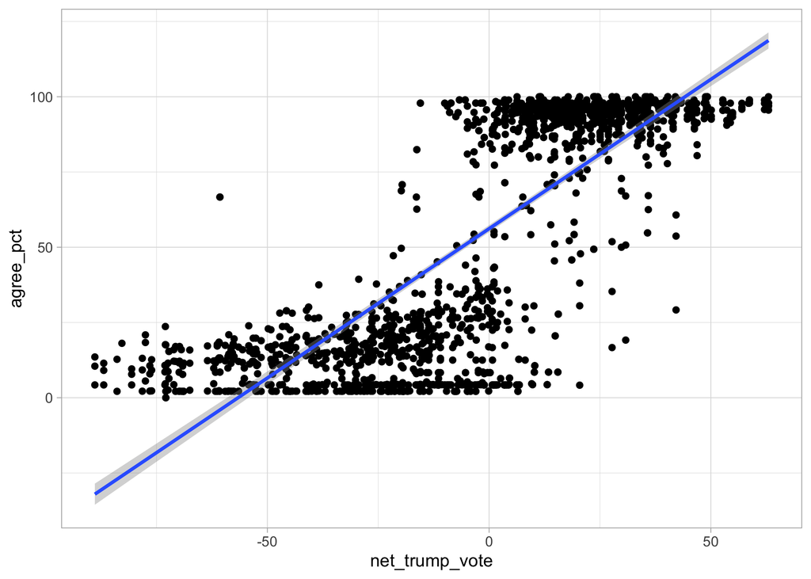

```r
scatter <- ggplot(data = congress)+
  aes(x = net_trump_vote, y = agree_pct)+
  geom_point()+
  geom_smooth(method = "lm")+
  theme_light()

scatter
```

## Question 5

Find the correlation between `agree_pct` and `net_trump_vote`. Hint: if using `tidyverse`, like calculating any statistic, we want the `summarize()` the data.

```r
# using base R
cor(congress$net_trump_vote, congress$agree_pct)
```

```
## [1] 0.7784996
```

```r
# using tidyverse
congress %>%
  summarize(correlation = cor(net_trump_vote, agree_pct))
```

| correlation |
| --- |
| 0.7784996 |

# Regression

## Question 6

We want to predict the following model:

$$\widehat{\text{agree_pct}}= \hat{\beta_0}+\hat{\beta_1} \,\text{net_trump_vote}$$
Run a regression and save it as an object. Then get a `summary()` of the object.

```r
reg <- lm(agree_pct ~ net_trump_vote, data = congress)

reg %>%
  summary()
```

```
##
## Call:
## lm(formula = agree_pct ~ net_trump_vote, data = congress)
##
## Residuals:
##     Min      1Q  Median      3Q     Max
## -72.261 -16.975   3.761  19.851  70.728
##
## Coefficients:
##                Estimate Std. Error t value Pr(>|t|)
## (Intercept)    56.16451    0.60307   93.13   <2e-16 ***
## net_trump_vote  0.99218    0.01922   51.63   <2e-16 ***
## ---
## Signif. codes:  0 '***' 0.001 '**' 0.01 '*' 0.05 '.' 0.1 ' ' 1
##
## Residual standard error: 25.1 on 1733 degrees of freedom
## Multiple R-squared:  0.6061, Adjusted R-squared:  0.6058
## F-statistic:  2666 on 1 and 1733 DF,  p-value: < 2.2e-16
```

### Part A

What is $\hat{\beta_0}$ for this model? What does it mean in the context of our question?

```r
# I just want to show you how to extract these and put it into text with markdown
# This relies on the code in Question 7 Part B
library(broom)
reg_tidy <- reg %>%
  tidy()

beta_0_hat <- reg_tidy %>% # save this as beta_0_hat
  slice(1) %>% # look only at first row (intercept)
  pull(estimate) %>% # extract the value of the estimate
  round(., 2) # round to 2 decimal places

beta_0_hat # look at it
```

```
## [1] 56.16
```

The estimated regression is:

$$\widehat{\text{agree_pct}_i} = 56.16 + 0.99 \, \text{net_trump_vote}_i$$

$\hat{\beta_0}$ is 56.16. On the graph, this is where the estimated line crosses the vertical axis. We would predict that for a `net_trump_vote` of 0 (i.e. a 50-50 tie in the district between Clinton & Trump), that district’s Member of Congress would vote **56%** of the time with President Trump.

### Part B

What is $\hat{\beta_1}$ for this model? What does it mean in the context of our question?

```r
beta_1_hat <- reg_tidy %>% # save this as beta_0_hat
  slice(2) %>% # look only at second row (net_trump_score)
  pull(estimate) %>% # extract the value of the estimate
  round(., 2) # round to 2 decimal places

beta_1_hat # look at it
```

```
## [1] 0.99
```

$\hat{\beta_1}$ is 0.99. This is the estimated slope of the line, and the marginal effect of (a 1 unit change in) $X$ on $Y$.

For every 1 additional point in `net_trump_vote` (i.e. a Trump win by 1 more point), that district’s Member of Congress would vote about **1%** more of the time with President Trump.

### Part C

What is $R^2$ for this model? What does it mean in the context of our question?

```r
# this uses the glance command in question 7 part C.

r_sq <- glance(reg) %>%
  pull(r.squared) %>%
  round(., 2)

r_sq # look at it
```

```
## [1] 0.61
```

$R^2$ is 0.61. This means that about 61% of the variation in `agree_pct` is explained by our model.

### Part D

What is the $SER$ for this model? What does it mean in the context of our question?

```r
# this uses the glance command in question 7 part C.

ser <- glance(reg) %>%
  pull(sigma) %>%
  round(.,2) # round to 2 decimals

ser # look at it
```

```
## [1] 25.1
```

SER $(\hat{\sigma_u})$ is 25.1. This means that the average prediction error (distance from any data point to the line) is 25 percentage points.

## Question 7

We can look at regression outputs in a tidier way, with the `broom` package.

### Part A

Install (if you have not yet done so) and load the `broom` package.

```r
# install.packages("broom")
library(broom)
```

### Part B

Run the function `tidy()` on your regression object (saved in question 6). Save this result as an object and then look at it.

```r
reg_tidy <- reg %>%
  tidy()

reg_tidy
```

| term | estimate | std.error | statistic | p.value |
| --- | --- | --- | --- | --- |
| (Intercept) | 56.1645133 | 0.60306814 | 93.13129 | 0 |
| net_trump_vote | 0.9921844 | 0.01921538 | 51.63492 | 0 |

### Part C

Run the `glance()` function on your original regression object. What does it show you? Find $R^2$ and the SER and confirm they are the same from the Base R `lm` output.

```r
reg %>%
  glance()
```

| r.squared | adj.r.squared | sigma | statistic | p.value | df | logLik | AIC | BIC | deviance | df.residual | nobs |
| --- | --- | --- | --- | --- | --- | --- | --- | --- | --- | --- | --- |
| 0.6060616 | 0.6058343 | 25.10093 | 2666.165 | 0 | 1 | -8052.598 | 16111.2 | 16127.57 | 1091889 | 1733 | 1735 |

It shows you summary statistics of the regression, particularly its goodness of fit.

- `r.squared` is the $R^2$ value
- `sigma` is the $SER \; (\hat{\sigma_u})$

That’s all we need for now.

### Part D

Now run the `augment()` function on your original regression object, and save this as an object. Look at it. What does it show you?

```r
reg_aug <- reg %>%
  augment()

reg_aug
```

| agree_pct | net_trump_vote | .fitted | .resid | .hat | .sigma | .cooksd | .std.resid |
| --- | --- | --- | --- | --- | --- | --- | --- |
| 97.872340 | 63.0000000 | 118.6721301 | -20.79978972 | 0.0029929687 | 25.10319 | 1.033746e-03 | -0.829888862 |
| 96.842105 | 63.0000000 | 118.6721301 | -21.83002488 | 0.0029929687 | 25.10268 | 1.138687e-03 | -0.870994118 |
| 100.000000 | 63.0000000 | 118.6721301 | -18.67213015 | 0.0029929687 | 25.10416 | 8.330742e-04 | -0.744997572 |
| 62.142857 | 9.4000000 | 65.4910466 | -3.34818950 | 0.0006424141 | 25.10805 | 5.722469e-06 | -0.133431902 |
| 54.166667 | 9.4000000 | 65.4910466 | -11.32437998 | 0.0006424141 | 25.10670 | 6.546245e-05 | -0.451298696 |
| 79.545455 | 9.4000000 | 65.4910466 | 14.05440790 | 0.0006424141 | 25.10591 | 1.008297e-04 | 0.560095649 |
| 97.857143 | 12.3000000 | 68.3683814 | 29.48876147 | 0.0006834260 | 25.09817 | 4.722680e-04 | 1.175208948 |
| 98.936170 | 12.3000000 | 68.3683814 | 30.56778883 | 0.0006834260 | 25.09743 | 5.074620e-04 | 1.218211181 |
| 95.652174 | 12.3000000 | 68.3683814 | 27.28379253 | 0.0006834260 | 25.09961 | 4.042825e-04 | 1.087334819 |
| 12.318841 | -40.0000000 | 16.4771376 | -4.15829702 | 0.0014578700 | 25.10798 | 2.006352e-05 | -0.165783923 |

[output cut: 1725 more lines]

It takes the original data points for `Y` and `X` and adds new variables with values for those observations: - `.fitted` is $\hat{Y_i|X}$, the predicted value for a specific `net_trump_vote` - `.resid` is $\hat{u_i}$, the residual or error for a specific `net_trump_vote`
$$\begin{align*}
\hat{u_i}&=Y_i-\hat{Y_i}\\
.resid &= agree\text{_}pct - .fitted\\
\end{align*}$$

That’s all we need right now.

## Question 8

Let’s use our `broom` results to calculate the goodness of fit statistics you found in question 6 to confirm.

Alternately, you can calculate $R^2$ as $1-\frac{SSE}{TSS}$ by taking 1 minus sum of squared $\hat{u_i}$ (`.resid` in that same `augment`ed object) over the variance of $\text{agree_pct}$.

**Optional**: If you really want to be fancy, make your own function to calculate the sum of squares of $\hat{Y}$ and $Y_i$ (instead of variance), as I did, with:

```r
sum_sq = function(x){sum((x - mean(x))^2)}
```

and then running this function on `agree_pct` and `.fitted`.

```r
# calculate R^2 as ratio of variances of predicted to actual Y values
reg_aug %>%
  summarize(var_y_hat = var(.fitted),
            var_y = var(agree_pct),
            R_sq = var_y_hat/var_y)
```

| var_y_hat | var_y | R_sq |
| --- | --- | --- |
| 968.7633 | 1598.457 | 0.6060616 |

```r
# using my custom sum of squares function
sum_sq = function(x){sum((x - mean(x))^2)}

# R^2 = ESS/TSS
reg_aug %>%
  summarize(ESS = sum_sq(.fitted),
            TSS = sum_sq(agree_pct),
            R_sq = ESS/TSS)
```

| ESS | TSS | R_sq |
| --- | --- | --- |
| 1679836 | 2771724 | 0.6060616 |

```r
# R^2 = 1 - (SSE/TSS)
reg_aug %>%
  summarize(SSE = sum(.resid^2),
            TSS = sum_sq(agree_pct),
            R_sq = 1-(SSE/TSS))
```

| SSE | TSS | R_sq |
| --- | --- | --- |
| 1091889 | 2771724 | 0.6060616 |

```r
# and of course, find R^2 by just squaring correlation coefficient
congress %>%
  summarize(correlation = cor(net_trump_vote, agree_pct),
            R_sq = correlation^2)
```

| correlation | R_sq |
| --- | --- |
| 0.7784996 | 0.6060616 |

## Question 9

Now let’s try presenting your results in a regression table. Install and load the `huxtable` package, and run the `huxreg()` command. Your main input is your regression object you saved in Question 6. Feel free to customize the output of this table (see the slides).

```r
#install.packages("huxtable")
library(huxtable)
# basic
huxreg(reg)
```

|  | (1) |
| --- | --- |
| (Intercept) | 56.165 *** |
|  | (0.603) |
| net_trump_vote | 0.992 *** |
|  | (0.019) |
| N | 1735 |
| R2 | 0.606 |
| logLik | -8052.598 |
| AIC | 16111.196 |
| *** p < 0.001; ** p < 0.01; * p < 0.05. |  |

```r
# some customization:
huxreg("Agree with President (Proportion)" = reg,
       coefs = c("Intercept" = "(Intercept)",
                 "Net Trump Vote" = "net_trump_vote"),
       statistics = c("n" = "nobs",
                      "R-squared" = "r.squared",
                      "SER" = "sigma"),
       number_format = 4)
```

|  | Agree with President (Proportion) |
| --- | --- |
| Intercept | 56.1645 *** |
|  | (0.6031) |
| Net Trump Vote | 0.9922 *** |
|  | (0.0192) |
| n | 1735 |
| R-squared | 0.6061 |
| SER | 25.1009 |
| *** p < 0.001; ** p < 0.01; * p < 0.05. |  |

# Regression Diagnostics

## Question 10

Now let’s start looking at the residuals of the regression.

### Part A

Take the `augment`ed regression object from Question 7D and use it as the source of your data to create a histogram with `ggplot()`, setting `aes(x = .resid)`. Does it look roughly normal?

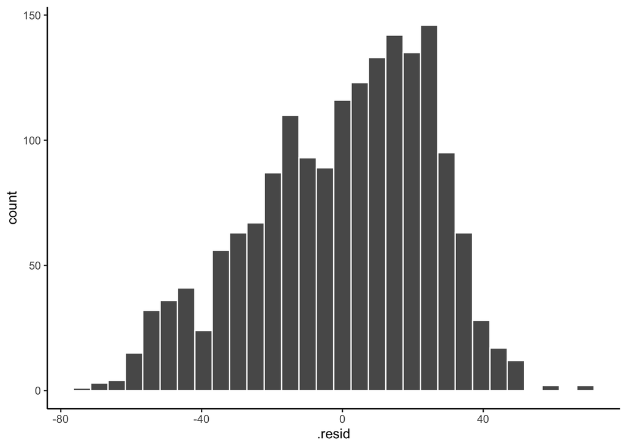

```r
ggplot(data = reg_aug)+
  aes(x = .resid)+
  geom_histogram(color = "white")+
  theme_classic()
```

### Part B

Take the `augment`ed regression object and make a residual plot, which is a scatterplot where `x` is the normal `x` variable, and `y` is the `.resid`. Feel free to add a horizontal line at 0 with `geom_hline(yintercept = 0)` as an additional layer.

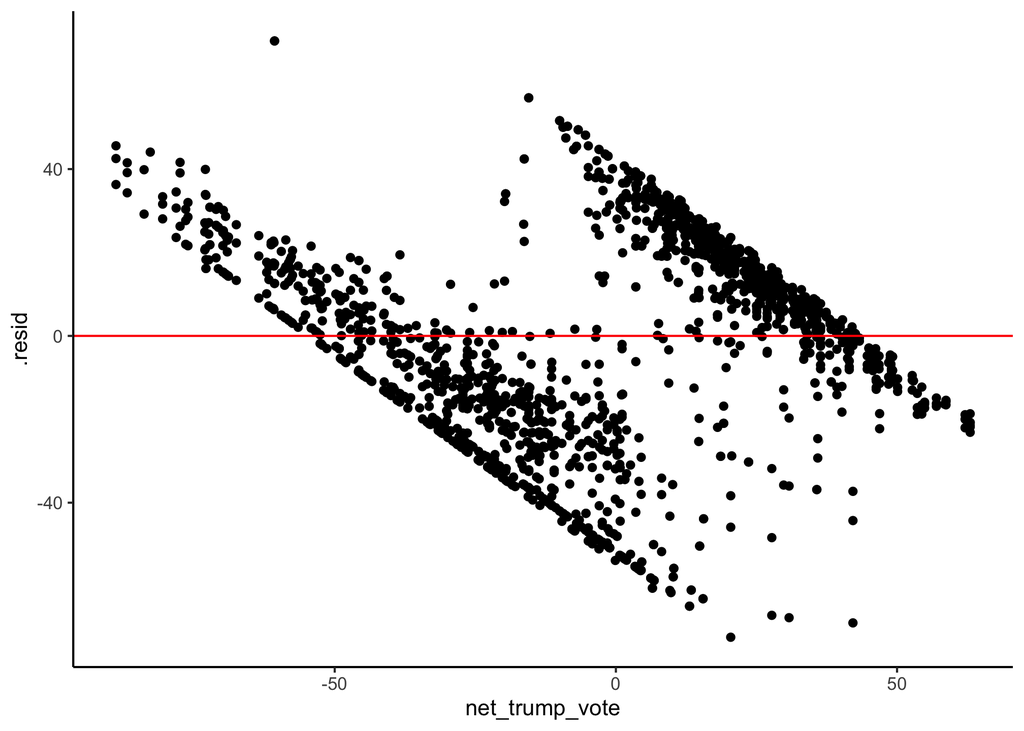

```r
ggplot(data = reg_aug)+
  aes(x = net_trump_vote, y = .resid)+
  geom_point()+
  geom_hline(yintercept = 0, color = "red")+
  theme_classic()
```

## Question 11

Now let’s check for heteroskedasticity.

### Part A

It does seem like it would be, looking at the residual plot, since there are clear downward-moving clusters of points that are at times above the line, then below the line, then above and below the line.

### Part B

Install and load the `lmtest` package and run `bptest()` on your saved `lm` object from Question 6. According to the test, is the data heteroskedastic or homoskedastic?

```r
# install.packages("lmtest")
library(lmtest)
bptest(reg)
```

```
##
##  studentized Breusch-Pagan test
##
## data:  reg
## BP = 6.0092, df = 1, p-value = 0.01423
```

Since the $p$-value was less than 0.05, we can reject the null hypothesis $H_0$ (that the errors are homoskedastic), and conclude that the errors are heteroskedastic. We will need to fix them if we want accurate standard errors.

### Part C

Now let’s make some heteroskedasticity-robust standard errors. Install and load the `estimatr` package and use the `lm_robust()` command (instead of the `lm()` command) to run a new regression (and save it). Make sure you add `se_type = "stata"` inside the command to calculate robust SEs (in the same way that the Stata software does…long story). Look at it. What changes?

```r
#install.packages("estimatr")
library(estimatr)

reg_rse <- lm_robust(agree_pct ~ net_trump_vote, data = congress, se_type="stata")
reg_rse
```

```
##                  Estimate Std. Error  t value Pr(>|t|)   CI Lower  CI Upper
## (Intercept)    56.1645133 0.60117565 93.42447        0 54.9854072 57.343619
## net_trump_vote  0.9921844 0.01493938 66.41403        0  0.9628833  1.021486
##                  DF
## (Intercept)    1733
## net_trump_vote 1733
```

The standard errors on both estimates $(\hat{\beta_0}$ and $\hat{\beta_1})$ change, but the estimates themselves do not change!

Note `t values` and `Pr(>|t|)` will change, and this command adds confidence intervals (`CI`) and degrees of freedom for $t$, `DF`, but we have not covered any of these yet!

### Part D

Now let’s see this in a nice regression table. Use `huxreg()` again, but add both your original regression and your regression saved in part C. Notice any changes?

```r
huxreg("Original" = reg,
       "Robust SEs" = reg_rse,
       number_format = 6) # need to see more decimal places!
```

|  | Original | Robust SEs |
| --- | --- | --- |
| (Intercept) | 56.164513 *** | 56.164513 *** |
|  | (0.603068) | (0.601176) |
| net_trump_vote | 0.992184 *** | 0.992184 *** |
|  | (0.019215) | (0.014939) |
| N | 1735 | 1735 |
| R2 | 0.606062 | 0.606062 |
| logLik | -8052.598116 |  |
| AIC | 16111.196232 |  |
| *** p < 0.001; ** p < 0.01; * p < 0.05. |  |  |

## Question 12

Now let’s check for outliers.

### Part B

Install and load the `car` package. Run the `outlierTest` command on your regression object. Does it detect any outliers?

```r
# install.packages("car")
library(car)
outlierTest(reg)
```

```
## No Studentized residuals with Bonferroni p < 0.05
## Largest |rstudent|:
##       rstudent unadjusted p-value Bonferroni p
## 1708 -2.886125          0.0039485           NA
```

### Part C

Look in your original data to match this outlier with an observation. Hint: use the `slice()` command, as the outlier test gave you an observation (row) number!

```r
congress %>%
  slice(1708)
```

| congress | chamber | bioguide | last_name | state | district | party | votes | agree_pct | predicted_agree | net_trump_vote |
| --- | --- | --- | --- | --- | --- | --- | --- | --- | --- | --- |
| 116 | senate | T000464 | Tester | MT |  | D | 24 | 4.17 | 0.751 | 20.4 |

## Question 13

(**Optional**: Flexing your tidyverse skills)

This data is still a bit messy. Let’s check your `tidyverse` skills again! For example, we’d probably like to plot our scatterplots with colors for Republican and Democratic party. Or plot by the House and the Senate.

### Part A

First, the variable `congress` (session of Congress) seems a bit off. Get a `count()` of `congress`.

```r
congress %>%
  count(congress)
```

| congress | n |
| --- | --- |
| 0 | 647 |
| 115 | 552 |
| 116 | 536 |

### Part B

Let’s get rid of the `0` values for `congress` (someone made a mistake coding this, probably).

```r
congress_tidy <- congress %>%
  filter(congress != 0)
```

### Part C

The variable `party` is also quite a mess. `count()` by `party` to see. Then let’s `mutate` a variable to make a better measure of political party - just `"Republican"`, `"Democrat"`, and `"Independent"`. Try doing this with the `case_when()` command (as your `mutate` formula).

The syntax for `case_when()` is to have a series of `condition ~ "Outcome"`, separated by commas. For example, one condition is to assign both `"Democrat"` and `"D"` to `"Democrat"`, as in `party %in% c("Democrat", "D") ~ "Democrat"`. You could also do this with a few `ifelse()` commands, but that’s a bit more awkward.] When you’re done `count()` by your new party variable to make sure it worked.

```r
# a mess!
congress %>%
  count(party)
```

| party | n |
| --- | --- |
| D | 528 |
| Democrat | 307 |
| I | 5 |
| Independent | 3 |
| R | 555 |
| Republican | 337 |

```r
# make it tidier
congress_tidy <- congress_tidy %>%
  mutate(pol_party = case_when(
    party %in% c("Democrat", "D") ~ "Democrat",
    party %in% c("Republican", "R") ~ "Republican",
    party %in% c("Independent", "I") ~ "Independent"
  ))

congress_tidy %>%
  count(pol_party)
```

| pol_party | n |
| --- | --- |
| Democrat | 528 |
| Independent | 5 |
| Republican | 555 |

### Part D

Now plot a scatterplot (same as Question 4) and set `color` to your party variable. Notice `R` uses its own default colors, which don’t match to the actual colors these political parties use! Make a vector where you define the party colors as follows:

```r
party_colors <- c("Democrat" = "blue",
                  "Republican" = "red",
                  "Independent" = "gray")
```

Then, run your plot again, adding the following layer to customize the colors `scale_colour_manual("Parties", values = party_colors)`. `"Parties"` is the title that will show up on the legend, feel free to edit it, or remove the legend with another layer `+guides(color = F)`.

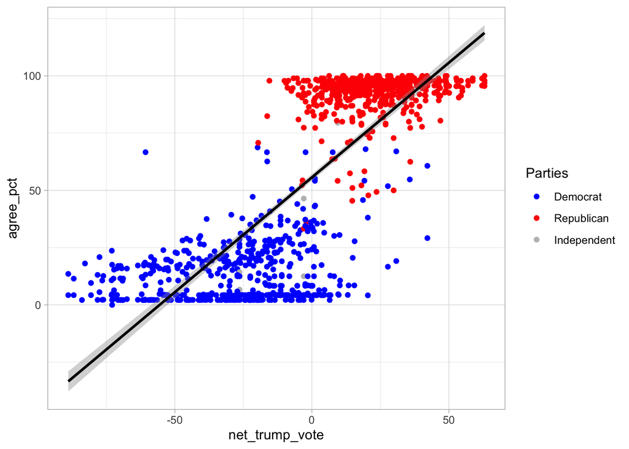

```r
party_colors <- c("Democrat" = "blue",
                  "Republican" = "red",
                  "Independent" = "gray")

p <- ggplot(data = congress_tidy)+
  aes(x = net_trump_vote, y = agree_pct)+
  geom_point(aes(color = pol_party))+
  geom_smooth(method = "lm", color = "black")+
  scale_colour_manual("Parties", values = party_colors)+
  theme_light()
p
```

### Part E

Now facet your scatterplot by `chamber` by adding a layer: `facet_wrap(~chamber)`.

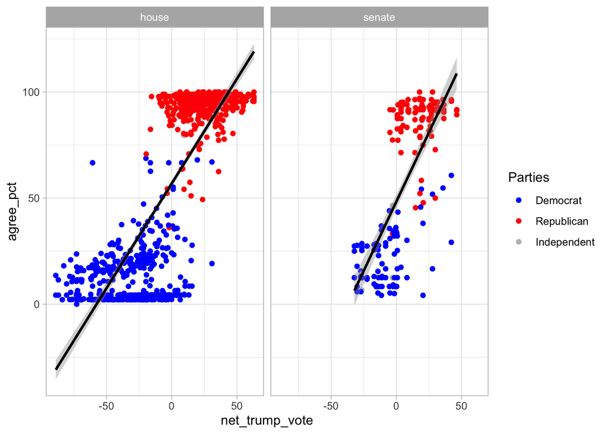

```r
p + facet_wrap(~chamber)
```

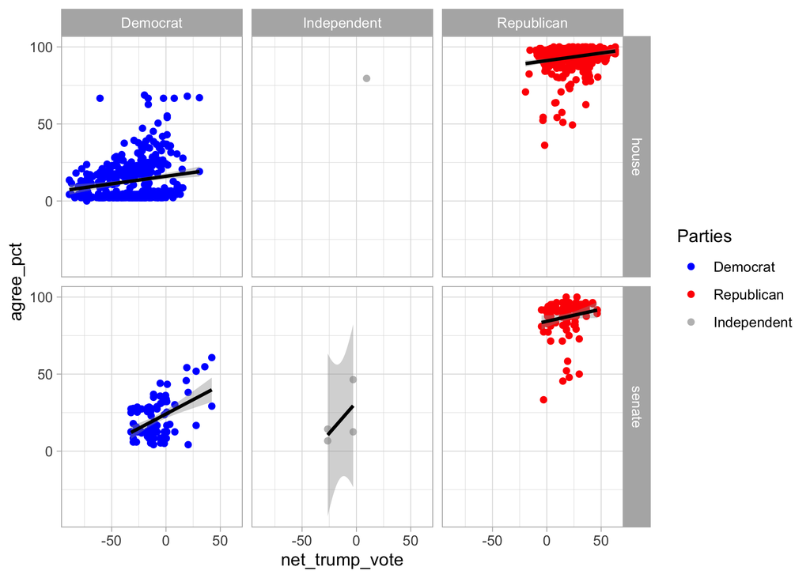

```r
# just for kicks
p+facet_grid(chamber~pol_party)
```